# Estimate actual redshifts from photometric data

We have photometric data -- magnitudes and colors. We will use this to estimate the actual redshift of the object as measured through its spectrum.

## Step wise procedure

1. Data preparation and processing
2. Pre-preparation: Have summary metrics ready.
3. Linear: Regression using Ordinary least squares
4. Non-linear: Let's do a Neural network in pytorch

```python
%matplotlib inline
import numpy as np
import matplotlib.pyplot as plt
import pandas as pd
import warnings
warnings.filterwarnings('ignore')
```

# Step 1: Download data

```python
!pip install gdown
```

```
  Installing build dependencies ... done
  Getting requirements to build wheel ... done
    Preparing wheel metadata ... done
```

```python
!gdown --id 1D7OZ_ibIjl-2clagDXHBgiX_-BxAycmK
```

```
Downloading...
From: https://drive.google.com/uc?id=1D7OZ_ibIjl-2clagDXHBgiX_-BxAycmK
To: /home/uvishal/Desktop/SummerSchool2021/Skyserver_12_15_2020 3 45 07 AM.csv
82.5MB [00:06, 13.6MB/s]
```

```python
!pip install scikit-learn --upgrade
```

```
     |████████████████████████████████| 22.2 MB 3.6 MB/s eta 0:00:01     |███████████████████▏            | 13.3 MB 2.6 MB/s eta 0:00:04
  Attempting uninstall: scikit-learn
    Found existing installation: scikit-learn 0.21.3
    Uninstalling scikit-learn-0.21.3:
      Successfully uninstalled scikit-learn-0.21.3
```

```python
Data = pd.read_csv("Skyserver_12_15_2020 3 45 07 AM.csv",comment="#")
```

```python
Data.head()
```

|  | objid | ra | dec | u | g | r | i | z | run | rerun | camcol | field | specobjid | class | redshift | plate | mjd | fiberid |
| --- | --- | --- | --- | --- | --- | --- | --- | --- | --- | --- | --- | --- | --- | --- | --- | --- | --- | --- |
| 0 | 1237678877245244171 | 318.951692 | 9.315146 | 19.51665 | 18.50036 | 17.95667 | 17.53139 | 17.32035 | 7777 | 301 | 5 | 53 | 819657923239110656 | GALAXY | 0.114299 | 728 | 52520 | 10 |
| 1 | 1237668332026986542 | 217.940001 | 14.608378 | 19.13548 | 18.55482 | 17.95603 | 17.68272 | 17.63717 | 5322 | 301 | 3 | 56 | 6154252554903769088 | QSO | 1.802680 | 5466 | 56033 | 304 |
| 2 | 1237664092899115053 | 129.948221 | 25.213328 | 19.54955 | 18.19434 | 17.83220 | 17.51329 | 17.47054 | 4335 | 301 | 3 | 130 | 2173034979993348096 | GALAXY | 0.070813 | 1930 | 53347 | 175 |
| 3 | 1237654604252119048 | 160.357788 | 3.567886 | 17.72343 | 16.65830 | 16.23667 | 16.07098 | 16.02797 | 2126 | 301 | 1 | 275 | 649647859372681216 | STAR | 0.000570 | 577 | 52367 | 13 |
| 4 | 1237661360769400880 | 226.001700 | 38.619699 | 16.60500 | 15.66234 | 15.39406 | 15.29443 | 15.29302 | 3699 | 301 | 2 | 227 | 5817649714997514240 | STAR | -0.000184 | 5167 | 56066 | 454 |

```python
#First, replace with nan
Data = Data.replace(-9999.0,np.nan)
Data.dropna(inplace=True)
```

# Step 2: Convert magnitudes to color.

This step is to ensure "flux" due to distance is removed, and relative intensities between different bands is taken.

```python
df = Data[['class','redshift']]
df['u_g'] = Data['u']-Data['g']
df['g_r'] = Data['g']-Data['r']
df['r_i'] = Data['r']-Data['i']
df['i_z'] = Data['i']-Data['z']

df = df.loc[df['class']=='QSO']
```

```python
df.head()
```

|  | class | redshift | u_g | g_r | r_i | i_z |
| --- | --- | --- | --- | --- | --- | --- |
| 1 | QSO | 1.802680 | 0.58066 | 0.59879 | 0.27331 | 0.04555 |
| 8 | QSO | 0.754256 | 0.20686 | 0.09017 | 0.12023 | 0.06721 |
| 28 | QSO | 1.681824 | 0.13062 | 0.00068 | 0.20351 | 0.02154 |
| 55 | QSO | 0.506626 | 0.23220 | 0.04590 | 0.14832 | 0.03768 |
| 57 | QSO | 0.395499 | 0.24153 | 0.55923 | 0.44332 | 0.50756 |

```python
df = df.drop('class',axis=1)
```

```python
df.columns
```

```
Index(['redshift', 'u_g', 'g_r', 'r_i', 'i_z'], dtype='object')
```

```python
from sklearn.preprocessing import StandardScaler
```

```python
input_raw = df[['u_g','g_r','r_i','i_z']].values
output_raw = df['redshift'].values
print(input_raw.shape,output_raw.shape)
```

```
(54536, 4) (54536,)
```

```python
output_raw = output_raw.reshape([-1,1])
```

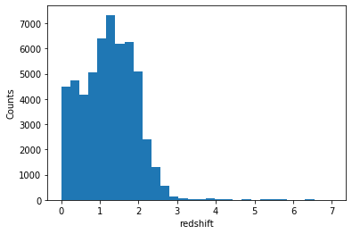

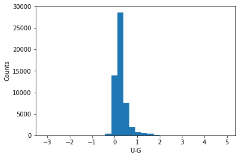

```python
_ = plt.hist(output_raw[:,0],30)
plt.xlabel("redshift")
plt.ylabel("Counts")
plt.figure()
_ = plt.hist(input_raw[:,0],30)
plt.xlabel("U-G")
plt.ylabel("Counts")
```

```python
scalerx = StandardScaler()
scalery = StandardScaler()

input_mod = scalerx.fit_transform(input_raw)
output_mod = scalery.fit_transform(output_raw)
```

### Train-test split

```python
idx = np.arange(input_mod.shape[0])

#----------- Shuffle the indices
np.random.seed(2796)
np.random.shuffle(idx)
idx = list(idx)
#-----------------
trainlocs = idx[:int(len(idx) * 0.85)]
xtrain = input_mod[trainlocs,:]
ytrain = output_mod[trainlocs]
print(xtrain.shape,ytrain.shape)

#------------------
testlocs = idx[int(len(idx) * 0.85):]
xtest = input_mod[testlocs]
ytest = output_mod[testlocs]
print(xtest.shape,ytest.shape)
```

```
(46355, 4) (46355, 1)
(8181, 4) (8181, 1)
```

```python
ytrain_og = scalery.inverse_transform(ytrain)
ytest_og = scalery.inverse_transform(ytest)
```

```python
from sklearn.metrics import mean_absolute_percentage_error,r2_score,mean_squared_error
def Performance(target,prediction):
    print(f"Mean square error: {mean_squared_error(target,prediction)}")
    print(f"Mean absolute percentage error: {mean_absolute_percentage_error(target,prediction)}")
    print(f"R2 score: {r2_score(target,prediction)}")
```

```python
def Make_scatter_plot(target,prediction):
    plt.figure()
    plt.scatter(target,prediction,s=2.0)
    plt.xlabel("Targets")
    plt.ylabel("predictions")
```

# First up, let us check how Linear regression works out

We will use $\color{#d08c60}{Scikit-learn}$ to perform linear regression. This assumes the form of our predictor as:

$$z_{pred,j} = W_{ij}m_{i} + b_j,$$

where $m_{i}$ are the individual colors for each sample, and $j$ corresponds to each sample.

```python
from sklearn.linear_model import LinearRegression
```

```python
LinReg = LinearRegression()
LinReg.fit(xtrain,ytrain)
```

```
LinearRegression()
```

```python
ytrain_pred = LinReg.predict(xtrain)
ytest_pred = LinReg.predict(xtest)
```

```python
ytrain_pred = scalery.inverse_transform(ytrain_pred)
ytest_pred = scalery.inverse_transform(ytest_pred)
```

```python
print("Training set statistics")
Performance(ytrain_og,ytrain_pred)
```

```
Training set statistics
Mean square error: 0.4341474455449827
Mean absolute percentage error: 1.6382026041507045
R2 score: 0.11960032422078937
```

```python
print("Testing set statistics")
Performance(ytest_og,ytest_pred)
```

```
Testing set statistics
Mean square error: 0.4130444409033818
Mean absolute percentage error: 2.8755175537844018
R2 score: 0.138727060676193
```

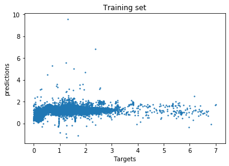

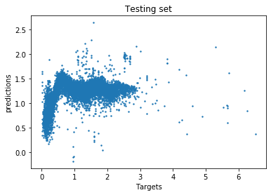

```python
Make_scatter_plot(ytrain_og,ytrain_pred)
plt.title("Training set")
Make_scatter_plot(ytest_og,ytest_pred)
plt.title("Testing set")
```

# Neural network

We shall use $\color{#dc2f02}{Pytorch}$ to make our neural network. You can use tensorflow or keras or whatever package you like -- pytorch is in vogue now, so we go ahead with it.

## Pytorch structure

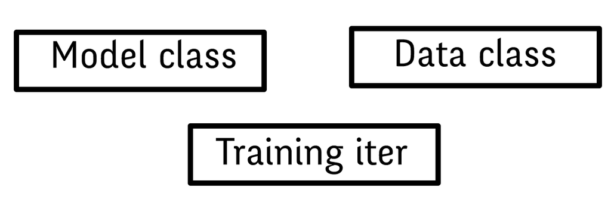

So basically, we need to write a small:

1. Data class, which will give us input and output for a given sample.
2. A model class which will define our network and generate output for a given input.
3. A *for* loop which will iterate over data and train the network.

```python
import torch
import torch.nn as nn
from torch.utils import data
```

```python
def _float(tensor):
    return torch.Tensor(tensor.astype(np.float32)).float()
```

```python
class ReDNN(nn.Module):
    def __init__(self,nin,nout):
        super(ReDNN,self).__init__()
        self.NN = nn.Sequential(
                    nn.Linear(nin,12),
                    nn.ELU(inplace=True),
                    nn.Linear(12,26),
                    nn.ELU(inplace=True),
                    nn.Linear(26,14),
                    nn.ELU(inplace=True),
                    nn.Linear(14,7),
                    nn.ELU(inplace=True),
                    nn.Linear(7,nout)
        )
    def forward(self,input_data):
        return self.NN(input_data)
```

```python
def MSE(true, pred):
    return ((true - pred)**2).mean().detach().cpu().numpy()

def Wrap_performance(true,pred):
    return Performance(true.detach().cpu().numpy(),pred.detach().cpu().numpy())

def loss_fn(true,pred):
    return ((true - pred)**2).mean()
```

```python
torch.manual_seed(0)
```

```
<torch._C.Generator at 0x7f07b36607b0>
```

```python
device = torch.device("cuda" if torch.cuda.is_available() else "cpu")
print(device)
```

```
cpu
```

```python
class Data(data.Dataset):
    def __init__(self,features,target):
        self.features = _float(features).to(device)
        self.target = _float(target).to(device)
        self.nout = target.shape[-1]
        self.nin = features.shape[-1]
    def __len__(self):
        return self.features.shape[0]
    def __getitem__(self,index):
        return self.features[index],self.target[index]
```

```python
batch_size = 50000
lr = 1e-3
num_epochs = 10000
```

```python
train_set = Data(xtrain,ytrain)
test_set = Data(xtest,ytest)

training_loader = data.DataLoader(train_set,batch_size=batch_size,shuffle=True)
test_loader = data.DataLoader(test_set,batch_size=test_set.features.shape[0],shuffle=True)
```

```python
#This defines our model
Redshift_model = ReDNN(train_set.nin,train_set.nout)
Redshift_model = Redshift_model.to(device).float()
print(Redshift_model)
```

```
ReDNN(
  (NN): Sequential(
    (0): Linear(in_features=4, out_features=12, bias=True)
    (1): ELU(alpha=1.0, inplace=True)
    (2): Linear(in_features=12, out_features=26, bias=True)
    (3): ELU(alpha=1.0, inplace=True)
    (4): Linear(in_features=26, out_features=14, bias=True)
    (5): ELU(alpha=1.0, inplace=True)
    (6): Linear(in_features=14, out_features=7, bias=True)
    (7): ELU(alpha=1.0, inplace=True)
    (8): Linear(in_features=7, out_features=1, bias=True)
  )
)
```

```python
optimizer = torch.optim.Adam(Redshift_model.parameters(),lr=lr)
```

```python
!nvidia-smi
```

```
/bin/sh: 1: nvidia-smi: not found
```

```python
from tqdm import tqdm
```

```python
training_stats = []
testing_stats = []
for i in tqdm(np.arange(num_epochs)):
    mse_loss = []
    for features,target in training_loader:
        optimizer.zero_grad()

        # features = features.to(device)
        # target = target.to(device)

        predictions = Redshift_model(features)

        loss = loss_fn(target, predictions)

        loss.backward()
        optimizer.step()

        mse_loss.append(loss.detach().cpu().numpy())
    training_stats.append(np.mean(mse_loss))
    with torch.no_grad():
        mse_loss = []
        for features,target in test_loader:
            # features = features.to(device)
            # target = target.to(device)

            predictions = Redshift_model(features)

            loss = loss_fn(target, predictions)
            mse_loss.append(loss.detach().cpu().numpy())

        testing_stats.append(np.mean(mse_loss))
    if i%100==0:
        print(f"Training loss: {training_stats[-1]}")
        print(f"Testing loss: {testing_stats[-1]}")
```

```
Training loss: 1.0429177284240723
Testing loss: 1.010424017906189
```

```
Training loss: 0.805014967918396
Testing loss: 0.7586883306503296
```

```
Training loss: 0.5787550806999207
Testing loss: 0.5313055515289307
```

```
Training loss: 0.5105524063110352
Testing loss: 0.47404029965400696
```

```
Training loss: 0.47775566577911377
Testing loss: 0.44577157497406006
```

```
Training loss: 0.4440903067588806
Testing loss: 0.4172672927379608
```

```
Training loss: 0.42394933104515076
Testing loss: 0.3995254933834076
```

```
Training loss: 0.4142536222934723
Testing loss: 0.3914772570133209
```

```
Training loss: 0.40838703513145447
Testing loss: 0.3869340419769287
```

```
Training loss: 0.40470030903816223
Testing loss: 0.3835708796977997
```

```
Training loss: 0.4009409248828888
Testing loss: 0.3813799321651459
```

```
Training loss: 0.39838942885398865
Testing loss: 0.3798573613166809
```

```
Training loss: 0.39623042941093445
Testing loss: 0.3786638379096985
```

```
Training loss: 0.3943498134613037
Testing loss: 0.37764668464660645
```

```
Training loss: 0.39277997612953186
Testing loss: 0.3767212927341461
```

```
Training loss: 0.3900764286518097
Testing loss: 0.3751850724220276
```

```
Training loss: 0.38888201117515564
Testing loss: 0.37455302476882935
```

```
Training loss: 0.38688868284225464
Testing loss: 0.37344351410865784
```

```
Training loss: 0.38601821660995483
Testing loss: 0.3729109764099121
```

```
Training loss: 0.38519349694252014
Testing loss: 0.3723355233669281
```

```
Training loss: 0.3844228684902191
Testing loss: 0.3718632757663727
```

```
Training loss: 0.38375142216682434
Testing loss: 0.3714633882045746
```

```
Training loss: 0.3831177055835724
Testing loss: 0.3710906505584717
```

```
Training loss: 0.3825947940349579
Testing loss: 0.3710826337337494
```

```
Training loss: 0.3819925785064697
Testing loss: 0.3704615533351898
```

```
Training loss: 0.38147443532943726
Testing loss: 0.3701893985271454
```

```
Training loss: 0.3809804618358612
Testing loss: 0.369965523481369
```

```
Training loss: 0.3805215060710907
Testing loss: 0.3697221577167511
```

```
Training loss: 0.38060641288757324
Testing loss: 0.37025347352027893
```

```
Training loss: 0.379647821187973
Testing loss: 0.3693101108074188
```

```
Training loss: 0.37922748923301697
Testing loss: 0.3691261112689972
```

```
Training loss: 0.37881237268447876
Testing loss: 0.3689388632774353
```

```
Training loss: 0.3783932328224182
Testing loss: 0.3688707947731018
```

```
Training loss: 0.3787841498851776
Testing loss: 0.36892756819725037
```

```
Training loss: 0.3776698708534241
Testing loss: 0.36871811747550964
```

```
Training loss: 0.3773338794708252
Testing loss: 0.3686498701572418
```

```
Training loss: 0.37703242897987366
Testing loss: 0.3685665428638458
```

```
Training loss: 0.37672001123428345
Testing loss: 0.3685436546802521
```

```
Training loss: 0.3766272962093353
Testing loss: 0.3687886893749237
```

```
Training loss: 0.37616315484046936
Testing loss: 0.368480384349823
```

```
Training loss: 0.3759009838104248
Testing loss: 0.36847397685050964
```

```
Training loss: 0.3756312429904938
Testing loss: 0.36847519874572754
```

```
Training loss: 0.37539058923721313
Testing loss: 0.3684680461883545
```

```
Training loss: 0.37514591217041016
Testing loss: 0.36847543716430664
```

```
Training loss: 0.3763253688812256
Testing loss: 0.3710669279098511
```

```
Training loss: 0.37463852763175964
Testing loss: 0.36849600076675415
```

```
Training loss: 0.37440380454063416
Testing loss: 0.3685078024864197
```

```
Training loss: 0.37427279353141785
Testing loss: 0.36858683824539185
```

```
Training loss: 0.37396812438964844
Testing loss: 0.368507444858551
```

```
Training loss: 0.37375494837760925
Testing loss: 0.36851006746292114
```

```
Training loss: 0.37355926632881165
Testing loss: 0.36850547790527344
```

```
Training loss: 0.373360812664032
Testing loss: 0.36851486563682556
```

```
Training loss: 0.3740957975387573
Testing loss: 0.36875662207603455
```

```
Training loss: 0.37297114729881287
Testing loss: 0.36849460005760193
```

```
Training loss: 0.37277549505233765
Testing loss: 0.3685016334056854
```

```
Training loss: 0.3725890815258026
Testing loss: 0.36846673488616943
```

```
Training loss: 0.3724072277545929
Testing loss: 0.3684818148612976
```

```
Training loss: 0.3722202479839325
Testing loss: 0.36849445104599
```

```
Training loss: 0.3720431625843048
Testing loss: 0.3684445321559906
```

```
Training loss: 0.3718603253364563
Testing loss: 0.3684447705745697
```

```
Training loss: 0.37169891595840454
Testing loss: 0.3684428334236145
```

```
Training loss: 0.37150198221206665
Testing loss: 0.3684423267841339
```

```
Training loss: 0.3721151649951935
Testing loss: 0.3694412112236023
```

```
Training loss: 0.37114617228507996
Testing loss: 0.36844587326049805
```

```
Training loss: 0.37096482515335083
Testing loss: 0.36846739053726196
```

```
Training loss: 0.37079960107803345
Testing loss: 0.3685048222541809
```

```
Training loss: 0.37062007188796997
Testing loss: 0.36847764253616333
```

```
Training loss: 0.3708796203136444
Testing loss: 0.3685731291770935
```

```
Training loss: 0.37029075622558594
Testing loss: 0.3684837520122528
```

```
Training loss: 0.37012389302253723
Testing loss: 0.3685140311717987
```

```
Training loss: 0.3700970411300659
Testing loss: 0.36936911940574646
```

```
Training loss: 0.36979568004608154
Testing loss: 0.3685391843318939
```

```
Training loss: 0.36962783336639404
Testing loss: 0.36857864260673523
```

```
Training loss: 0.36946842074394226
Testing loss: 0.36856886744499207
```

```
Training loss: 0.36928999423980713
Testing loss: 0.3686386048793793
```

```
Training loss: 0.36912277340888977
Testing loss: 0.3687869906425476
```

```
Training loss: 0.3689476549625397
Testing loss: 0.36871597170829773
```

```
Training loss: 0.3687781095504761
Testing loss: 0.36879971623420715
```

```
Training loss: 0.3685983121395111
Testing loss: 0.3688943684101105
```

```
Training loss: 0.36843061447143555
Testing loss: 0.3689413070678711
```

```
Training loss: 0.3682593107223511
Testing loss: 0.36903420090675354
```

```
Training loss: 0.3681250810623169
Testing loss: 0.36903655529022217
```

```
Training loss: 0.3679257333278656
Testing loss: 0.36918210983276367
```

```
Training loss: 0.3685164153575897
Testing loss: 0.37005478143692017
```

```
Training loss: 0.3675999045372009
Testing loss: 0.36931735277175903
```

```
Training loss: 0.3674386143684387
Testing loss: 0.36938953399658203
```

```
Training loss: 0.36773666739463806
Testing loss: 0.3706035017967224
```

```
Training loss: 0.36712881922721863
Testing loss: 0.36951300501823425
```

```
Training loss: 0.36697572469711304
Testing loss: 0.36958932876586914
```

```
Training loss: 0.36685261130332947
Testing loss: 0.36975985765457153
```

```
Training loss: 0.3666819632053375
Testing loss: 0.36970487236976624
```

```
Training loss: 0.3665861487388611
Testing loss: 0.36973869800567627
```

```
Training loss: 0.3664065897464752
Testing loss: 0.36981743574142456
```

```
Training loss: 0.3662739396095276
Testing loss: 0.3698887825012207
```

```
Training loss: 0.3661373555660248
Testing loss: 0.36996743083000183
```

```
Training loss: 0.36601170897483826
Testing loss: 0.3699497580528259
```

```
Training loss: 0.36588054895401
Testing loss: 0.3700923025608063
```

```
Training loss: 0.36575615406036377
Testing loss: 0.3704265058040619
```

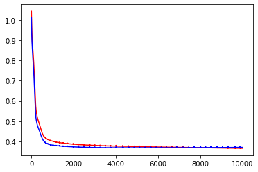

```python
plt.plot(training_stats,'r')
plt.plot(testing_stats,'b')
```

```python
xtmp,ytrain_scaled = train_set[:]
ytrain_scaled = ytrain_scaled.detach().cpu().numpy()
ytrain_pred = Redshift_model(xtmp.to(device)).detach().cpu().numpy()

xtmp,ytest_scaled = test_set[:]
ytest_scaled = ytest_scaled.detach().cpu().numpy()
ytest_pred = Redshift_model(xtmp.to(device)).detach().cpu().numpy()
```

```python
ytrain_pred = scalery.inverse_transform(ytrain_pred)
ytest_pred = scalery.inverse_transform(ytest_pred)

ytrain_unscaled = scalery.inverse_transform(ytrain_scaled)
ytest_unscaled = scalery.inverse_transform(ytest_scaled)
```

```python
print("Training set statistics")
Performance(ytrain_unscaled,ytrain_pred)
```

```
Training set statistics
Mean square error: 0.17955991625785828
Mean absolute percentage error: 1.4118765592575073
R2 score: 0.6358737369203818
```

```python
print("Testing set statistics")
Performance(ytest_unscaled,ytest_pred)
```

```
Testing set statistics
Mean square error: 0.18180879950523376
Mean absolute percentage error: 3.0428426265716553
R2 score: 0.6208955050640239
```

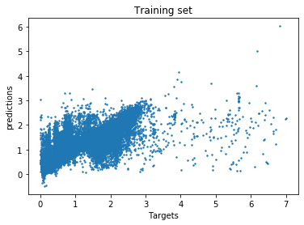

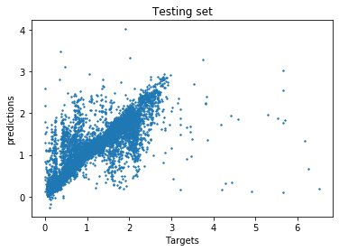

```python
Make_scatter_plot(ytrain_unscaled,ytrain_pred)
plt.title("Training set")
Make_scatter_plot(ytest_unscaled,ytest_pred)
plt.title("Testing set")
```